# Temperature Data - The Unknown Station: Blagovescensk

17276

12/3/2019

## Introduction

We will analyze the temperature data of oldest weather station in China listed in the National Oceanic and Atmospheric Administration database to determine if there is an observed warming trend.

## Background on the Weather Station

The Blagovescensk weather station (NOAA ID:GHCND:RSM00031510), is listed at N 50.25 E 127.5 at 130 m elevation in what appears to be a park in the Zhongyang Commercial district in Aihui, Heihe, Heilongjiang, China. It is near the bank of the Amur River just feet away from the Russian border in the northeastern part of China. On the NOAA website, the station is identified as a Chinese station, while the data in the spreadsheet appears to list Russia as the country of origin.

There is next to no information on the station outside of the NOAA website. Since the Russian city of Blagoveshchensk is right across the river from this station, it may be possible that the station was misnamed or Blagovescensk is an alternative Romanized spelling for the city. By searching ‘“Blagovescensk” weather’, one can go to the images section and find a link to a Russian weather site. According to weather-forcast.com, the Blagoveshchensk Weather Forecast has two stations immediately nearby the Russian city, both are in China. However, only one is listed on the NOAA site (Blagovescensk), and on the Russian weather site the link to the Blagovescensk station has an error message (the web page has been moved). The closest location is the Aihui (爱辉镇) station, which appears to be only a kilometer away from the Blagovescensk station and is not on the NOAA listing.

It is also the station with the earliest recorded data in China by sixty-one years. Since 1881, the Blagovescensk station has been recording temperature averages, later also recording minimums in 1890 and then maximums in 1914. There were 21 Russian weather stations that began recording data on January 1, 1881 (only one previous to this, in 1874), so it is possible that the Blagovescensk station on Chinese soil was somehow connected to these other Russian stations.

These ambiguities about the location and national identification of this particular weather station may be concerning for some people. However, this data has been cleared by the National Oceanic and Atmospheric Administration. According to NOAA, the findings are sound, at 97% overall coverage.

# Examining Outliers

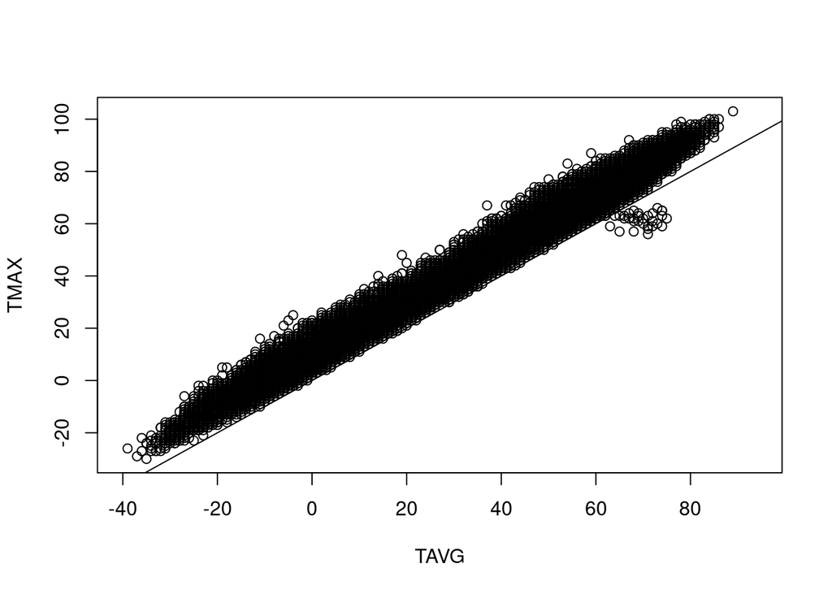

```r
plot(TMAX ~ TAVG, data = TEMP)
abline(0,1)
```

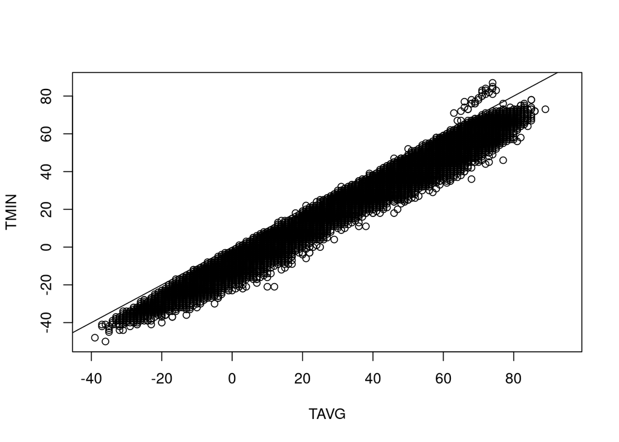

```r
plot(TMIN ~ TAVG, data = TEMP)
abline(0,1)
```

## Analysis of Maximum Temperature

It is unclear if maximum temperature if a singular peak, so it may not be representative of the temperature over an entire day. Since January 1, 1914 and 99% coverage.

```r
date.c = as.character(TEMP$DATE)
TEMP$NewDate <- as.Date(date.c, "%Y-%m-%d")
change = lm(TMAX ~ NewDate, data=TEMP)
summary(change)
```

```
##
## Call:
## lm(formula = TMAX ~ NewDate, data = TEMP)
##
## Residuals:
##     Min      1Q  Median      3Q     Max
## -72.531 -27.857   4.399  27.324  56.702
##
## Coefficients:
##              Estimate Std. Error t value Pr(>|t|)
## (Intercept) 4.438e+01  1.539e-01 288.351   <2e-16 ***
## NewDate     1.298e-04  1.378e-05   9.423   <2e-16 ***
## ---
## Signif. codes:  0 '***' 0.001 '**' 0.01 '*' 0.05 '.' 0.1 ' ' 1
##
## Residual standard error: 29.99 on 38433 degrees of freedom
##   (10752 observations deleted due to missingness)
## Multiple R-squared:  0.002305,   Adjusted R-squared:  0.002279
## F-statistic: 88.79 on 1 and 38433 DF,  p-value: < 2.2e-16
```

```r
TEMP$Month = format(as.Date(TEMP$NewDate), format = "%m")
TEMP$Year = format(TEMP$NewDate, format="%Y")

MonthTMAX.mean = aggregate(TMAX ~ Month + Year, TEMP, mean)
MonthTMAX.mean$YEAR = as.numeric(MonthTMAX.mean$Year)
MonthTMAX.mean$MONTH = as.numeric(MonthTMAX.mean$Month)
str(MonthTMAX.mean)
```

```
## 'data.frame':    1271 obs. of  5 variables:
##  $ Month: chr  "01" "02" "03" "04" ...
##  $ Year : chr  "1914" "1914" "1914" "1914" ...
##  $ TMAX : num  4.32 17.18 26.97 51.23 64.45 ...
##  $ YEAR : num  1914 1914 1914 1914 1914 ...
##  $ MONTH: num  1 2 3 4 5 6 7 8 9 10 ...
```

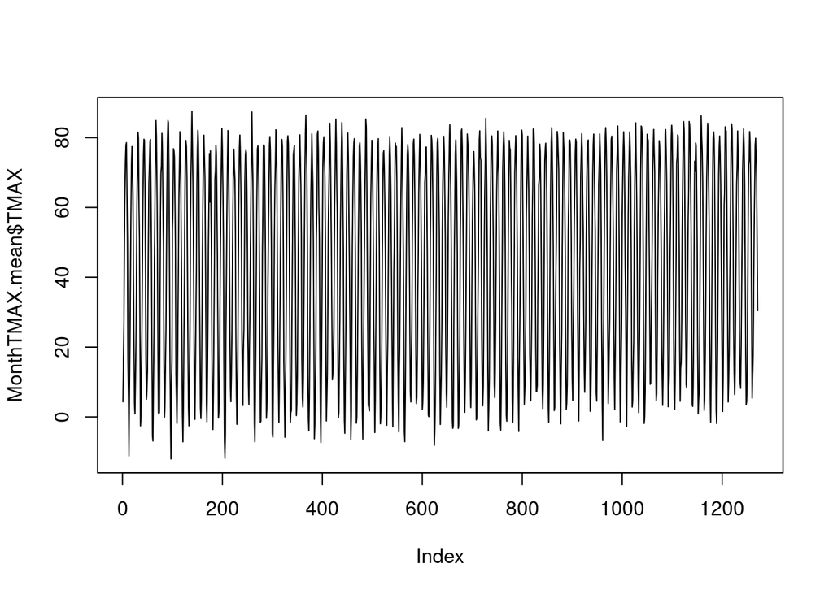

```r
plot(MonthTMAX.mean$TMAX, ty = "l")
```

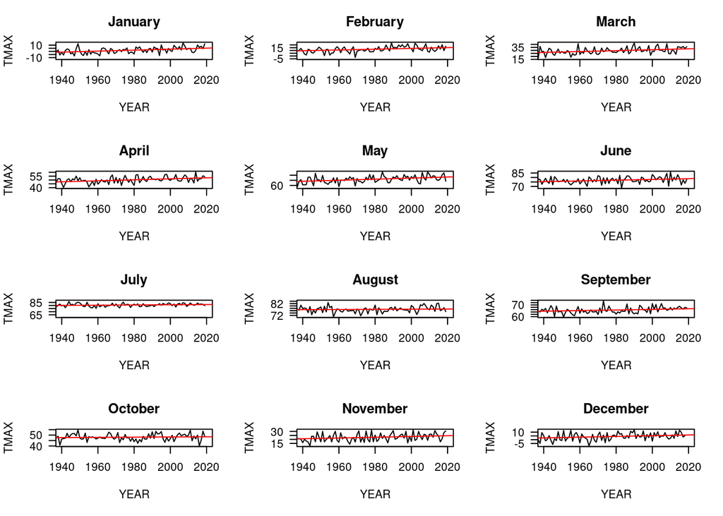

```r
Months = c("January", "February", "March", "April", "May", "June",
"July", "August", "September", "October", "November", "December")

par(mfrow=c(4,3), mar=c(5, 4, 3, 2) + 0.1)

TMAXresult <- NA

for (i in 1:12){
#plot(MonthTMAX.mean£TMAX[MonthTMAX.mean£Month==i], ty='l')
plot(TMAX~YEAR,
data=MonthTMAX.mean[MonthTMAX.mean$MONTH==i,],
ty='l', las=1, xlim=c(1940, 2020), main=Months[i])
Month.lm <- lm(TMAX~YEAR, data=MonthTMAX.mean[MonthTMAX.mean$MONTH==i,])
summary(Month.lm)
abline(coef(Month.lm), col="red")
TMAXresult <- rbind(TMAXresult,
cbind(Months[i], round(coef(Month.lm)[2], 4),
round(summary(Month.lm)$coefficients[2,4],4),
round(summary(Month.lm)$r.squared, 3)))
}
```

```r
May.lm <- lm(TMAX~YEAR, data=MonthTMAX.mean[MonthTMAX.mean$Month=="05",])
summary(May.lm)
```

```
##
## Call:
## lm(formula = TMAX ~ YEAR, data = MonthTMAX.mean[MonthTMAX.mean$Month ==
##     "05", ])
##
## Residuals:
##     Min      1Q  Median      3Q     Max
## -6.1699 -1.9945 -0.3006  2.1071  7.4823
##
## Coefficients:
##               Estimate Std. Error t value Pr(>|t|)
## (Intercept) -38.126196  19.471957  -1.958   0.0529 .
## YEAR          0.052653   0.009901   5.318 6.04e-07 ***
## ---
## Signif. codes:  0 '***' 0.001 '**' 0.01 '*' 0.05 '.' 0.1 ' ' 1
##
## Residual standard error: 3.119 on 104 degrees of freedom
## Multiple R-squared:  0.2138, Adjusted R-squared:  0.2062
## F-statistic: 28.28 on 1 and 104 DF,  p-value: 6.04e-07
```

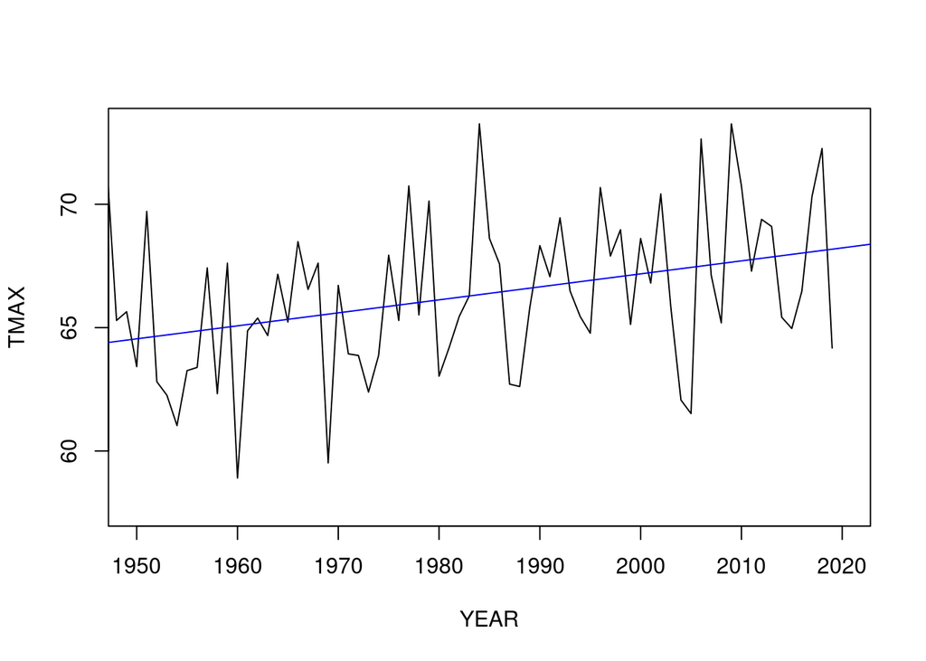

```r
plot(TMAX~YEAR, data=MonthTMAX.mean[MonthTMAX.mean$Month=="05",],
ty='l', xlim=c(1950, 2020))
abline(coef(May.lm), col="blue2")
```

## Analysis of Minimum Temperature

Although it may be the case the minimum temperatures spike at a low point and are also not representative of daily temperatures, lower temperatures generally are representative of a more gradual decline and increase before and after the observed minimum.

Since January 1, 1890 with 89% coverage

```r
MonthlyTMINMean = aggregate(TMIN ~ Month + Year, TEMP, mean)
MonthlyTMINMean$YEAR = as.numeric(MonthlyTMINMean$Year)
# Fixing the Format of Month and Year as numeric
MonthlyTMINMean$YEAR = as.numeric(MonthlyTMINMean$Year)
MonthlyTMINMean$MONTH = as.numeric(MonthlyTMINMean$Month)
head(MonthlyTMINMean)
```

```
##   Month Year      TMIN YEAR MONTH
## 1    01 1890 -24.26316 1890     1
## 2    02 1890 -18.58824 1890     2
## 3    03 1890   0.20000 1890     3
## 4    05 1890  38.13043 1890     5
## 5    06 1890  53.33333 1890     6
## 6    07 1890  59.29167 1890     7
```

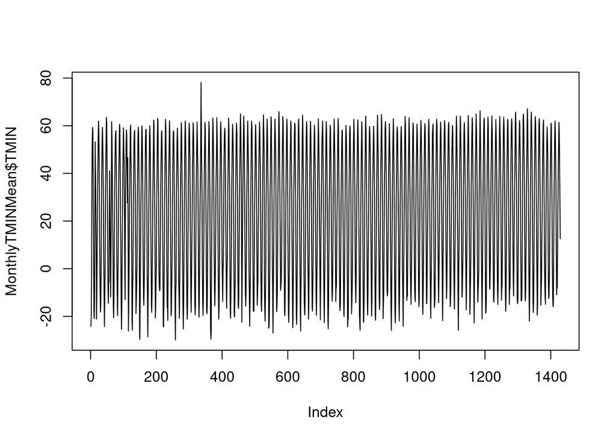

```r
plot(MonthlyTMINMean$TMIN, ty='l')
```

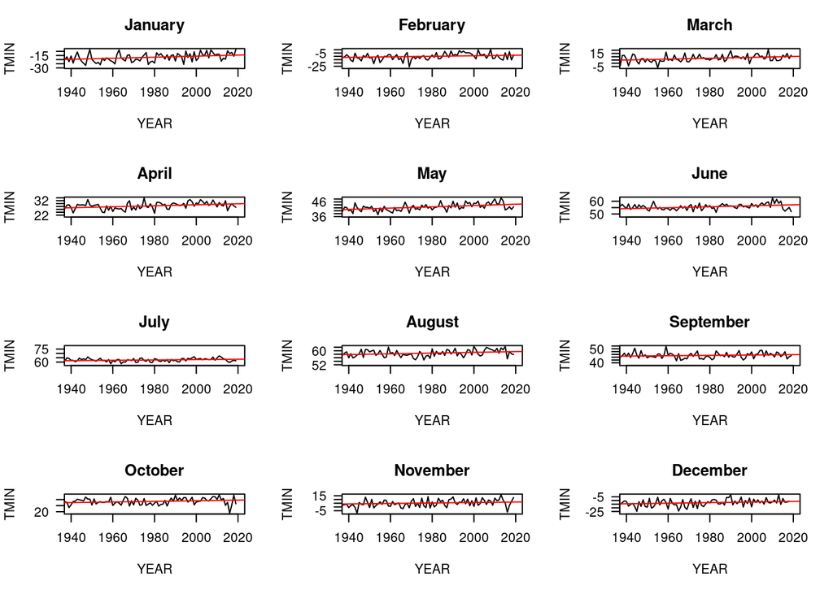

```r
par(mfrow=c(4,3), mar=c(5, 4, 3, 2) + 0.1)

TMINresult <- NA

for (i in 1:12){
#plot(MonthTMAX.mean£TMAX[MonthTMAX.mean£Month==i], ty='l')
plot(TMIN~YEAR,
data=MonthlyTMINMean[MonthlyTMINMean$MONTH==i,],
ty='l', las=1, xlim=c(1940, 2020), main=Months[i])
Month.lm.min <- lm(TMIN~YEAR, data=MonthlyTMINMean[MonthlyTMINMean$MONTH==i,])
summary(Month.lm.min)
abline(coef(Month.lm.min), col="red")
TMINresult <- rbind(TMINresult,
cbind(Months[i], round(coef(Month.lm.min)[2], 4),
round(summary(Month.lm.min)$coefficients[2,4],4),
round(summary(Month.lm.min)$r.squared, 3)))
}
```

## Analysis of Average Temperature

Since January 1, 1881 with 97% coverage RSM00031510 50.2500 127.5000 130.0 BLAGOVESCENSK 31510

```r
MonthlyTAVGMean = aggregate(TAVG ~ Month + Year, TEMP, mean)
MonthlyTAVGMean$YEAR = as.numeric(MonthlyTAVGMean$Year)
# Fixing the Format of Month and Year as numeric
MonthlyTAVGMean$YEAR = as.numeric(MonthlyTAVGMean$Year)
MonthlyTAVGMean$MONTH = as.numeric(MonthlyTAVGMean$Month)
head(MonthlyTAVGMean)
```

```
##   Month Year       TAVG YEAR MONTH
## 1    01 1881 -10.600000 1881     1
## 2    02 1881  -5.285714 1881     2
## 3    03 1881  14.612903 1881     3
## 4    04 1881  38.050000 1881     4
## 5    05 1881  49.892857 1881     5
## 6    06 1881  59.714286 1881     6
```

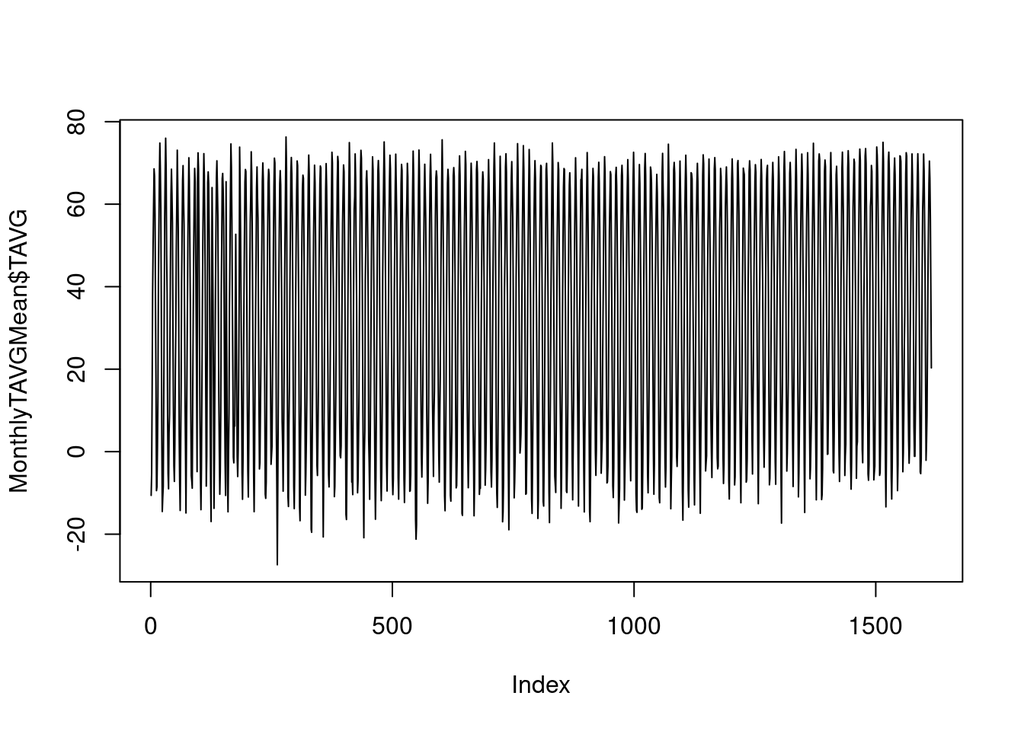

```r
plot(MonthlyTAVGMean$TAVG, ty='l')
```

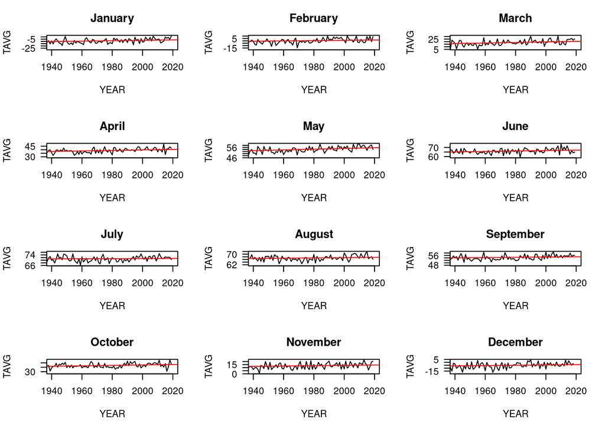

| Month | TAVGSlope | TAVG_P | TMAXSlope | TMAX_P | TMINSlope | TMIN_P |
| --- | --- | --- | --- | --- | --- | --- |
| January | 0.0456 | 0.0001 | 0.0791 | 0.0000 | 0.0639 | 0.0000 |
| February | 0.0327 | 0.0034 | 0.0706 | 0.0000 | 0.0396 | 0.0022 |
| March | 0.0522 | 0.0000 | 0.0768 | 0.0000 | 0.0667 | 0.0000 |
| April | 0.0363 | 0.0000 | 0.065 | 0.0000 | 0.034 | 0.0000 |
| May | 0.0356 | 0.0000 | 0.0527 | 0.0000 | 0.044 | 0.0000 |
| June | 0.0242 | 0.0000 | 0.0412 | 0.0001 | 0.0379 | 0.0000 |
| July | 0.0035 | 0.4620 | 0.0176 | 0.0816 | 0.0208 | 0.0013 |
| August | 0.0102 | 0.0194 | 0.0071 | 0.3857 | 0.021 | 0.0000 |
| September | 0.0105 | 0.0235 | 0.026 | 0.0024 | 0.0127 | 0.0213 |
| October | 0.0251 | 0.0000 | 0.0091 | 0.3488 | 0.0253 | 0.0003 |
| November | 0.0284 | 0.0028 | 0.0481 | 0.0014 | 0.0319 | 0.0067 |
| December | 0.0277 | 0.0081 | 0.048 | 0.0018 | 0.0406 | 0.0015 |

```r
par(mfrow=c(4,3), mar=c(5, 4, 3, 2) + 0.1)

TAVGresult <- NA

for (i in 1:12){
plot(TAVG~YEAR,
data=MonthlyTAVGMean[MonthlyTAVGMean$MONTH==i,],
ty='l', las=1, xlim=c(1940, 2020), main=Months[i])
Month.lm.avg <- lm(TAVG~YEAR, data=MonthlyTAVGMean[MonthlyTAVGMean$MONTH==i,])
summary(Month.lm.avg)
abline(coef(Month.lm.avg), col="red")
TAVGresult <- rbind(TAVGresult,
cbind(Months[i], round(coef(Month.lm.avg)[2], 4),
round(summary(Month.lm.avg)$coefficients[2,4],4),
round(summary(Month.lm.avg)$r.squared, 3)))
}
```

# Literature Cited

Li Q.2009. Assessment of surface air warming in northeast China, with emphasis on the impacts of urbanization. Theor & Appl. Climato. 99: 469-478. Yang X. 2007. Adaptation of agriculture to warming in Northeast China. Climatic Chan. 84: 45-58. Zhai P. 1999. Changes of Climate Extremes in China. Climatic Chan. 42: 203-218. Zhu C. 2012. Recent weakening of northern East Asian summer monsoon: A possible response to global warming. Geophy. Res. Lett. 39 (9): 1-6.